# Sesgos en Diseños Observacionales para Inferencia Causal en Investigación Educativa

Disertación en PSQF

Bladimir

# El problema de la inferencia causal

## *Correlación no implica causalidad*

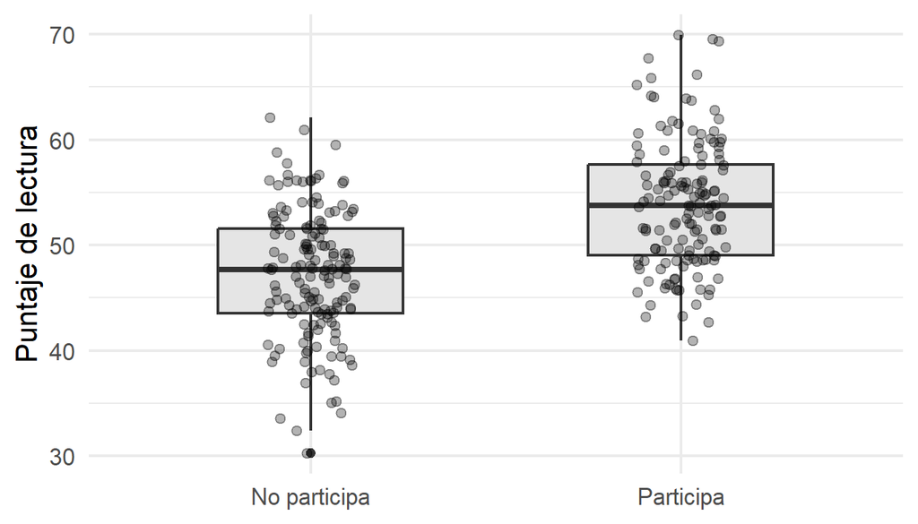

Los estudiantes que participan en el programa obtienen 6.7 puntos más en promedio, aunque en estos datos simulados **el efecto verdadero del programa es cero**. La diferencia proviene de la *motivación*, que influye tanto en la participación como en el puntaje.

## Pero, ¿qué significa causalidad?

- La frase “correlación no implica causalidad” dice lo que la causalidad **no es**, pero no dice lo que **es**.
- Una definición útil es *contrafactual*: El efecto de un programa (i.e., tratamiento) sobre un estudiante es la diferencia entre lo que ocurre si participa y lo que *habría ocurrido* si no participa (Rubin 1974; Holland 1986):

$$\delta_i = Y_i^1 - Y_i^0$$

- **Problema fundamental de la inferencia causal.** Para cada estudiante (e.g., unidad *i*) observamos solo uno de los dos resultados potenciales (Holland 1986).
- Por lo tanto, la inferencia causal es un problema de datos faltantes, y siempre depende de supuestos (Rubin 2005; Imbens y Rubin 2015).
- La idea de David Hume de *regularidad* y *sucesión* no basta para distinguir causa de asociación: un evento causa otro cuando ambos aparecen juntos de manera constante, cuando están próximos en el tiempo y el espacio, y cuando la supuesta causa siempre precede al efecto (Hume 1748). Ejemplo:

> *El canto del gallo y la salida del sol cumplen estas tres condiciones, ya que todos los días el gallo canta y, poco después, el sol aparece en el horizonte*.
- Sin embargo, nadie afirmaría que el gallo hace salir el sol. Ambos eventos responden a una causa común, el ciclo de rotación de la Tierra, que anuncia el amanecer al gallo y determina la salida del sol (Pearl y Mackenzie 2018). Si silenciáramos al gallo, ¿dejaría de salir el sol?

## De efectos individuales a efectos promedio

- Como $\delta_i$ no es observable, el interés se traslada a promedios poblacionales, llamados **estimandos**:

$$ATE = E[Y_i^1 - Y_i^0] \qquad ATT = E[Y_i^1 - Y_i^0 \mid D_i = 1]$$

- La diferencia simple de medias combina el efecto con otros componentes o fuentes de sesgo (Angrist y Pischke 2009; Cunningham 2021):

$$E[Y_i \mid D_i = 1] - E[Y_i \mid D_i = 0] = ATE + \underbrace{\text{sesgo de selección}}_{\text{quiénes participan}} + \underbrace{\text{sesgo por efectos heterogéneos}}_{\text{a quiénes beneficia}}$$

- Cada diseño causal es, en el fondo, una estrategia para justificar que esos términos adicionales son cero.

# Inferencia causal en diseño de experimentos y en ciencias sociales

## Dos tradiciones con condiciones muy distintas

| Aspecto | Diseño de experimentos | Ciencias sociales y educación |
| --- | --- | --- |
| Asignación al tratamiento | Controlada por el investigador, aleatoria (Fisher 1935) | Decidida por personas, instituciones o reglas de elegibilidad |
| Unidades | Parcelas, plantas, animales, pacientes | Estudiantes anidados en aulas, escuelas y comunidades |
| Interferencia entre unidades | Fácil de controlar | Frecuente, por pares y contexto (problemas con SUTVA) |
| Versiones del tratamiento | Estandarizadas | Implementación variable entre sitios |
| Restricciones | Técnicas | Éticas, políticas y logísticas |
| Diseño típico | Experimento aleatorizado | Diseño observacional |

## La aleatorización como punto de referencia

- La aleatorización garantiza por diseño que la asignación sea independiente de los resultados potenciales (Rubin 1974; Imbens y Rubin 2015):

$$(Y_i^1, Y_i^0) \perp\!\!\!\perp D_i$$

- En diseños observacionales, esa independencia **no está garantizada** y debe sustituirse por una característica del diseño y un conjunto de supuestos (Kim y Steiner 2016; Shadish, Cook, y Campbell 2002):
  - Selección en observables (pareamiento, puntaje de propensión)
  - Un punto de corte en una variable de asignación (regresión discontinua)
  - Una fuente externa de variación (variables instrumentales)
- Como sugiere Rubin (2008), el estudio observacional debería diseñarse **como si** fuera un experimento.

# El tabú del lenguaje causal

## Decir sin decir

- En muchas disciplinas se evita declarar objetivos causales y se reemplazan por términos como *asociado con*, *predice*, *se relaciona con* o *influye en* (Grosz, Rohrer, y Thoemmes 2020).
- Sin embargo, las conclusiones y recomendaciones suelen ser causales de forma implícita.
- La consecuencia principal es que **los supuestos necesarios para justificar una conclusión causal quedan ocultos** y no pueden ser examinados (Grosz, Rohrer, y Thoemmes 2020; Pearl y Mackenzie 2018).
- Este tabú tiene raíces históricas, como la asociación entre causalidad y experimentación, y la visión de la causalidad como un caso especial de asociación perfecta (Pearl 2009).

## Algunas prácticas frecuentes

- **Ensalada causal.** Incluir en una regresión todas las covariables disponibles e interpretar el coeficiente del tratamiento como efecto causal (McElreath 2020; Cinelli, Forney, y Pearl 2024).
- **Falacia de la Tabla 2.** Interpretar causalmente todos los coeficientes de un mismo modelo (Westreich y Greenland 2013).
- **Herramientas sin principios.** Usar modelos de ecuaciones estructurales o diagramas de rutas sin discutir sus implicancias causales (Pearl 2010).
- **Diseños bien conocidos, pero incompletos.** Se aplican regresión discontinua o puntajes de propensión sin explicitar el sistema causal ni los supuestos de identificación (Keller y Branson 2024; Steiner et al. 2017).

# Motivación de la disertación

## Tres problemas que se repiten

**Desalineación**

La pregunta de investigación, el diseño y el análisis no conversan entre sí. Se estima una cantidad que no corresponde a la pregunta original (Lundberg, Johnson, y Stewart 2021).

**Falta de flujo de trabajo**

No existe un procedimiento explícito y compartido para desarrollar un diseño observacional, desde la pregunta hasta la estimación (Keller y Branson 2024).

**Falta de taxonomía**

Los sesgos se discuten uno a uno, con nombres distintos según la disciplina, y casi siempre centrados en la estimación (Greenland 2003; Elwert y Winship 2014).

## ¿Por qué importa en educación?

- Las evaluaciones de impacto informan decisiones sobre financiamiento, continuidad de programas y rendición de cuentas.
- En educación, los datos observacionales son la norma y no la excepción.
- La discusión metodológica se concentra en la estimación, donde el sesgo puede cuantificarse, y deja de lado la definición y la identificación (Winship y Morgan 1999; Grosz, Rohrer, y Thoemmes 2020).
- **Ningún estimador puede corregir un estimando mal definido**.

# Propósito y objetivos

## Propósito

Contribuir al desarrollo de diseños observacionales para inferencia causal en educación mediante una **taxonomía de los sesgos** que pueden surgir en la **definición, identificación y estimación** de efectos causales, organizada en torno al **flujo de trabajo DIE**.

## Preguntas de investigación

1. ¿Cuáles son los principales sesgos que afectan las etapas y transiciones entre la definición, identificación y estimación de efectos causales en diseños observacionales?
2. ¿Qué implicancias tienen estos sesgos para el desarrollo de un diseño observacional?
3. ¿Qué decisiones permiten prevenir o reducir estas fuentes de sesgo?

# La definición de efecto causal depende del marco

## Tres tradiciones

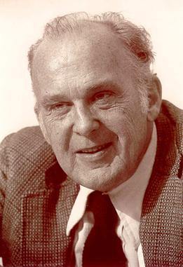

**Donald T. Campbell**

Validez y amenazas

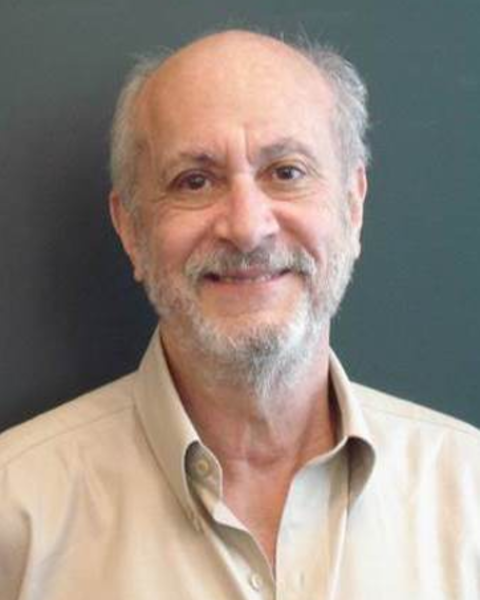

**Donald B. Rubin**

Resultados potenciales

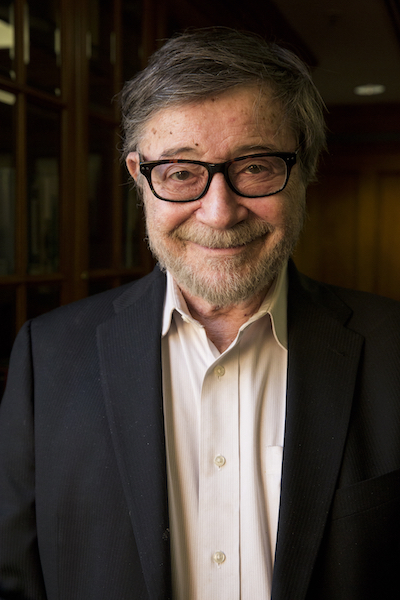

**Judea Pearl**

Modelos causales estructurales

## ¿Qué es un efecto causal en cada marco?

|  | Campbell | Rubin | Pearl |
| --- | --- | --- | --- |
| Pregunta central | ¿Qué amenazas pueden explicar el resultado? | ¿Qué habría pasado sin el tratamiento? | ¿Qué ocurre si intervenimos el sistema? |
| Efecto causal | Diferencia atribuible al tratamiento una vez descartadas explicaciones alternativas | Comparación de resultados potenciales, $Y^1 - Y^0$ | Distribución bajo intervención, $P(y \mid do(x))$ |
| Herramienta | Tipología de validez y diseños cuasiexperimentales | Notación de resultados potenciales y mecanismo de asignación | Grafos acíclicos dirigidos y ecuaciones estructurales |
| Énfasis | Diseño y validez | Definición del estimando | Identificación |
| Referencias | Campbell (1957); Shadish, Cook, y Campbell (2002) | Rubin (1974); Holland (1986) | Pearl (1995); Pearl (2009) |

## Marcos complementarios

- Los tres marcos no son competidores, sino que iluminan etapas distintas del trabajo causal (Shadish y Sullivan 2012; Steiner et al. 2017).
- La notación de resultados potenciales es especialmente útil para **definir** estimandos.
- Los grafos causales son especialmente útiles para **identificar** estimandos y examinar supuestos (Pearl 1995; Keller y Branson 2024).
- La tradición de Campbell recuerda que el **diseño** precede al análisis estadístico.
- La disertación integra estos aportes en un solo flujo de trabajo.

# El flujo de trabajo DIE

## Componentes de un diseño observacional

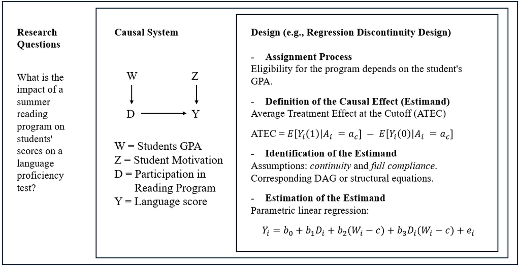

## Definición, identificación y estimación

| Etapa | Qué se hace | Resultado | Herramientas |
| --- | --- | --- | --- |
| **D**efinición | Traducir la pregunta en una cantidad causal precisa | Estimando ($\tau$), por ejemplo ATE, ATT, LATE | Resultados potenciales |
| **I**dentificación | Expresar el estimando en función de datos observables bajo supuestos | Cantidad estadística ($\theta$) | DAG, criterio de puerta trasera, supuestos del diseño |
| **E**stimación | Aplicar un procedimiento estadístico a los datos | Estimación ($\hat{\theta}$) | Regresión, pareamiento, ponderación, regresión local |

- Las decisiones de cada etapa restringen las decisiones de la etapa siguiente (Keller y Branson 2024; Pearl 2010; Lundberg, Johnson, y Stewart 2021)

## El error total de un estudio

$$\hat{\theta} - \tau^{*} = \underbrace{(\hat{\theta} - \theta)}_{\text{estimación}} + \underbrace{(\theta - \tau)}_{\text{identificación}} + \underbrace{(\tau - \tau^{*})}_{\text{definición}}$$

- $\tau^{*}$ es la cantidad causal implícita en la pregunta de investigación.
- Solo el primer término puede evaluarse directamente con herramientas estadísticas.
- Un estimador insesgado para $\theta$ **no protege** contra errores de identificación ni de definición (Lundberg, Johnson, y Stewart 2021).
- Las decisiones detrás de cada término no son independientes, lo que da lugar a sesgos entre etapas.

# Taxonomía de sesgos

## Sesgos según su ubicación en el flujo DIE

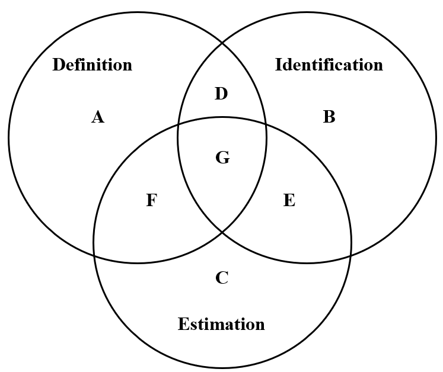

## Sesgos dentro de cada etapa

| Área | Etapa | Ejemplos |
| --- | --- | --- |
| A | Definición | Violación de SUTVA, mecanismo de asignación no documentado, ausencia de definición formal del estimando, estimando no sostenido por el diseño |
| B | Identificación | Violación de supuestos de identificación, sesgo por variable omitida, sesgo de selección endógena, sesgo por sobrecontrol, falta de evidencia o de datos para identificar |
| C | Estimación | Forma funcional incorrecta, sesgo en muestras finitas, potencia insuficiente, violación de supuestos del modelo estadístico (por ejemplo, ignorar el anidamiento) |

Referencias principales en Heckman (1979), Rosenbaum (1984), Elwert y Winship (2014), Greenland (2003) y Hernán y Robins (2020).

## Sesgos entre etapas

| Área | Etapas | Ejemplos |
| --- | --- | --- |
| D | Definición e identificación | Desalineación entre el estimando del sistema causal y los efectos que el diseño puede sostener; la identificación requiere supuestos o información que el sistema causal o el diseño no satisfacen |
| E | Identificación y estimación | Problemas de diseño muestral y representatividad, medidas inadecuadas o poco confiables del resultado o del tratamiento |
| F | Definición y estimación | Falta de datos para estimar el estimando de interés, desalineación entre el estimando definido y lo que realmente estima el modelo |
| G | Las tres etapas | Desalineación general entre estimando, diseño, supuestos, datos disponibles y estimación |

- Muchos de estos sesgos **no son cuantificables** y deben prevenirse con argumentos y decisiones explícitas.

# Novedad y contribuciones

## ¿Qué aporta esta disertación?

- **Organiza los sesgos según dónde se originan**.
- **Visibiliza los sesgos entre etapas** (áreas D a G), que la literatura apenas reconoce.
- **Explicita el flujo de trabajo DIE** como un marco unificado para diseños observacionales en educación.
- **Integra marcos** (Campbell, Rubin y Pearl) en un procedimiento práctico.
- **Ofrece preguntas concretas** a productores y consumidores de evidencia, como revisores, tomadores de decisiones y directivos escolares.
- **Ilustra las consecuencias** de cada sesgo con ejemplos aplicados en educación.

## Referencias

Angrist, Joshua D, y Jörn-Steffen Pischke. 2009. *Mostly harmless econometrics: An empiricist’s companion*. Princeton university press.

Campbell, Donald T. 1957. «Factors relevant to the validity of experiments in social settings». *Psychological bulletin* 54 (4): 297.

Cinelli, Carlos, Andrew Forney, y Judea Pearl. 2024. «A Crash Course in Good and Bad Controls». *Sociological Methods & Research* 53 (3): 1071-1104. https://doi.org/10.1177/00491241221099552.

Cunningham, Scott. 2021. *Causal Inference: The Mixtape*. New Haven, CT: Yale University Press.

Elwert, Felix, y Christopher Winship. 2014. «Endogenous selection bias: The problem of conditioning on a collider variable». *Annual review of sociology* 40 (1): 31-53. https://doi.org/10.1146/annurev-soc-071913-043455.

Fisher, Ronald A. 1935. *The Design of Experiments*. Edinburgh: Oliver; Boyd.

Greenland, Sander. 2003. «Quantifying biases in causal models: classical confounding vs collider-stratification bias». *Epidemiology* 14 (3): 300-306. https://doi.org/10.1097/01.EDE.0000042804.12056.6C.

Grosz, Michael P, Julia M Rohrer, y Felix Thoemmes. 2020. «The taboo against explicit causal inference in nonexperimental psychology». *Perspectives on Psychological Science* 15 (5): 1243-55. https://doi.org/https://doi.org/10.1177/1745691620921521.

Heckman, James J. 1979. «Sample selection bias as a specification error». *Econometrica: Journal of the econometric society*, 153-61. https://doi.org/https://doi.org/10.2307/1912352.

Hernán, Miguel A, y James M Robins. 2020. *Causal Inference: What If*. Boca Raton, FL: Chapman & Hall/CRC.

Holland, Paul W. 1986. «Statistics and causal inference». *Journal of the American statistical Association* 81 (396): 945-60.

Hume, David. 1748. *An Enquiry Concerning Human Understanding*. London: A. Millar.

Imbens, Guido W., y Donald B. Rubin. 2015. *Causal Inference for Statistics, Social, and Biomedical Sciences: An Introduction*. New York, NY: Cambridge University Press. https://doi.org/10.1017/CBO9781139025751.

Keller, Bryan, y Zach Branson. 2024. «Defining, identifying, and estimating causal effects with the potential outcomes framework: a review for education research». *Asia Pacific Education Review* 25 (3): 575-94. https://doi.org/https://doi.org/10.1007/s12564-024-09957-2.

Kim, Yongnam, y Peter Steiner. 2016. «Quasi-Experimental Designs for Causal Inference». *Educational Psychologist* 51 (3–4): 395-405. https://doi.org/10.1080/00461520.2016.1207177.

Lundberg, Ian, Rebecca Johnson, y Brandon M Stewart. 2021. «What is your estimand? Defining the target quantity connects statistical evidence to theory». *American Sociological Review* 86 (3): 532-65. https://doi.org/https://doi.org/10.1177/00031224211004187.

McElreath, Richard. 2020. *Statistical Rethinking: A Bayesian Course with Examples in R and Stan*. 2.ª ed. Boca Raton, FL: CRC Press.

Pearl, Judea. 1995. «Causal Diagrams for Empirical Research». *Biometrika* 82 (4): 669-710. https://doi.org/10.1093/biomet/82.4.669.

———. 2009. *Causality: Models, Reasoning, and Inference*. 2.ª ed. New York, NY: Cambridge University Press.

———. 2010. «The foundations of causal inference». *Sociological Methodology* 40 (1): 75-149.

Pearl, Judea, y Dana Mackenzie. 2018. *The book of why*. Allen Lane London.

Rosenbaum, Paul R. 1984. «The consequences of adjustment for a concomitant variable that has been affected by the treatment». *Journal of the Royal Statistical Society Series A: Statistics in Society* 147 (5): 656-66. https://doi.org/https://doi.org/10.2307/2981697.

Rubin, Donald B. 1974. «Estimating causal effects of treatments in randomized and nonrandomized studies». *Journal of educational Psychology* 66 (5): 688. https://doi.org/https://psycnet.apa.org/doi/10.1037/h0037350.

———. 2005. «Causal inference using potential outcomes: Design, modeling, decisions». *Journal of the American statistical Association* 100 (469): 322-31. https://doi.org/10.1198/016214504000001880.

———. 2008. «For objective causal inference, design trumps analysis». *The Annals of Applied Statistics* 2 (3): 808-40. https://doi.org/http://dx.doi.org/10.1214/08-AOAS187.

Shadish, William R, Thomas D Cook, y Donald T Campbell. 2002. *Experimental and Quasi-Experimental Designs for Generalized Causal Inference*. Boston, MA: Houghton Mifflin.

Shadish, William R, y Kristynn J Sullivan. 2012. «Theories of causation in psychological science». https://doi.org/10.1037/13619-003.

Steiner, Peter M, Yongnam Kim, Courtney E Hall, y Dan Su. 2017. «Graphical models for quasi-experimental designs». *Sociological methods & research* 46 (2): 155-88.

Westreich, Daniel, y Sander Greenland. 2013. «The table 2 fallacy: presenting and interpreting confounder and modifier coefficients». *American journal of epidemiology* 177 (4): 292-98. https://doi.org/https://doi.org/10.1093/aje/kws412.

Winship, Christopher, y Stephen L Morgan. 1999. «The estimation of causal effects from observational data». *Annual review of sociology* 25 (1): 659-706. https://doi.org/https://doi.org/10.1146/annurev.soc.25.1.659.